# Assignment 1

Now on with this week’s exercises.

# Using R as a calculator

1. Convert the following temperatures given in degrees Fahrenheit to Celsius: 45, 96, 451

```r
#
#
#
#
#
(45 - 32) * 5/9
```

```
## [1] 7.222222
```

```r
(96 - 32) * 5/9
```

```
## [1] 35.55556
```

```r
(451 - 32) * 5/9
```

```
## [1] 232.7778
```

Hint: just do what you’d normally do if you can’t remember the formula for converting between Celsius and Fahrenheit (Google in my case).

If you like, you can experiment with getting your R code right in the Console window first and then copy it into the code chunk above when you’re happy with it. It’s not crucial and getting it wrong in the R markdown is no big deal. You can always fix any problems (the most likely being forgetting to use parentheses or brackets in the right place) and re-run your code using the green arrow/triangle icon.

Check you’ve got the right answer by finding a web page with a handy conversion tool.

2. Similarly, convert the following temperatures in degrees Celsius to Fahrenheit: -65, 100, 20

```r
#
#
#
#
-65 * 9/5 + 32
```

```
## [1] -85
```

```r
100 * 9/5 + 32
```

```
## [1] 212
```

```r
20 * 9/5 + 32
```

```
## [1] 68
```

# Generating sequence vectors

3. Generate a sequence of numbers representing the days at which you take a measurement or a sample at 5-day intervals for about a year.

```r
1:73 * 5
```

```
##  [1]   5  10  15  20  25  30  35  40  45  50  55  60  65  70  75  80  85
## [18]  90  95 100 105 110 115 120 125 130 135 140 145 150 155 160 165 170
## [35] 175 180 185 190 195 200 205 210 215 220 225 230 235 240 245 250 255
## [52] 260 265 270 275 280 285 290 295 300 305 310 315 320 325 330 335 340
## [69] 345 350 355 360 365
```

Your friendly neighbourhood statistician has suggested that there should be an R function to do that. What is the function and how do you find out about it and what is the code you will use to create the sequence? Check the resulting vector.

```r
#
#
#
#
#
#
#
#
??sequence
sample_days <- seq(5, 365, by = 5)
sample_days
```

```
##  [1]   5  10  15  20  25  30  35  40  45  50  55  60  65  70  75  80  85
## [18]  90  95 100 105 110 115 120 125 130 135 140 145 150 155 160 165 170
## [35] 175 180 185 190 195 200 205 210 215 220 225 230 235 240 245 250 255
## [52] 260 265 270 275 280 285 290 295 300 305 310 315 320 325 330 335 340
## [69] 345 350 355 360 365
```

# Looking at types of objects

4. Run the code below and use the typeof() and/or class() function (check it’s help page) and see how R treats each newly-created vector?

```r
num_char <- c(1, 2, 3, "a")
num_logical <- c(1, 2, 3, TRUE)
char_logical <- c("a", "b", "c", TRUE)
tricky <- c(1, 2, 3, "4")
#
#
#
#
#
# Answers to the type coercion question below
#
#
#
#
#
typeof(num_char)
```

```
## [1] "character"
```

```r
class(num_char)
```

```
## [1] "character"
```

```r
num_char
```

```
## [1] "1" "2" "3" "a"
```

```r
typeof(num_logical)
```

```
## [1] "double"
```

```r
class(num_logical)
```

```
## [1] "numeric"
```

```r
num_logical
```

```
## [1] 1 2 3 1
```

```r
typeof(char_logical)
```

```
## [1] "character"
```

```r
class(char_logical)
```

```
## [1] "character"
```

```r
char_logical
```

```
## [1] "a"    "b"    "c"    "TRUE"
```

```r
typeof(tricky)
```

```
## [1] "character"
```

```r
class(tricky)
```

```
## [1] "character"
```

```r
tricky
```

```
## [1] "1" "2" "3" "4"
```

Create a new code chunk to test each of the vectors in a separate block. You can do this by using the ‘Insert’ menu just at the top of the pane for this markdown file and selecting R for an R code chunk, or by using the keyboard shortcut (on a Mac this is cmd-alt-i).

You should find that R coerces the data to a lowest common denominator - can you work out the hierarchy?

```r
# logical → numeric → character ← logical
```

# Plotting data

5. You have been asked to plot a graph of counts data measured over several days. The Principal Investigator has requested that certain symbols be used for each dataset being plotted (he’s a bit like that!). What command would you use to find out the parameter which sets this for the plot.default command and what is the parameter’s name?

```r
days <- c(1, 2, 4, 6, 8, 12, 16)
counts <- days ^ 2 + rnorm(days, mean = days)

#
#
#
#
#
#
#
#
# add your code here
?rnorm
rnorm(days, mean = days)
```

```
## [1]  1.188304  1.531116  3.131133  7.713132  9.808655 11.186189 15.733216
```

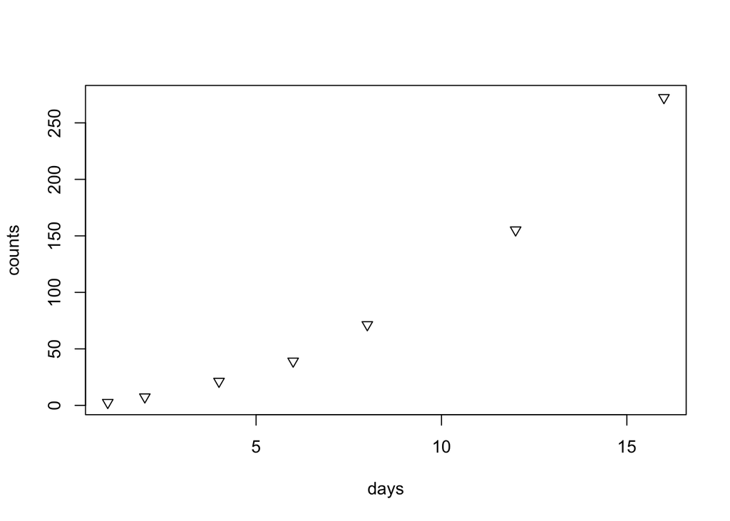

```r
#
help("plot.default")
?plot.default
#
plot.default(days,counts, pch=6)
```

Check out what we did in the above example for getting some example counts data points. Can you make sense of what is going on here? Look at the help page for the `rnorm` function.

Our counts data don’t really look like counts as they are not whole numbers. Find the function in R that can round these up or down to the closest whole number and apply it in the above code chunk.

```r
??round
round_days <- round(counts)
round_days
```

```
## [1]   3   7  21  39  71 155 272
```

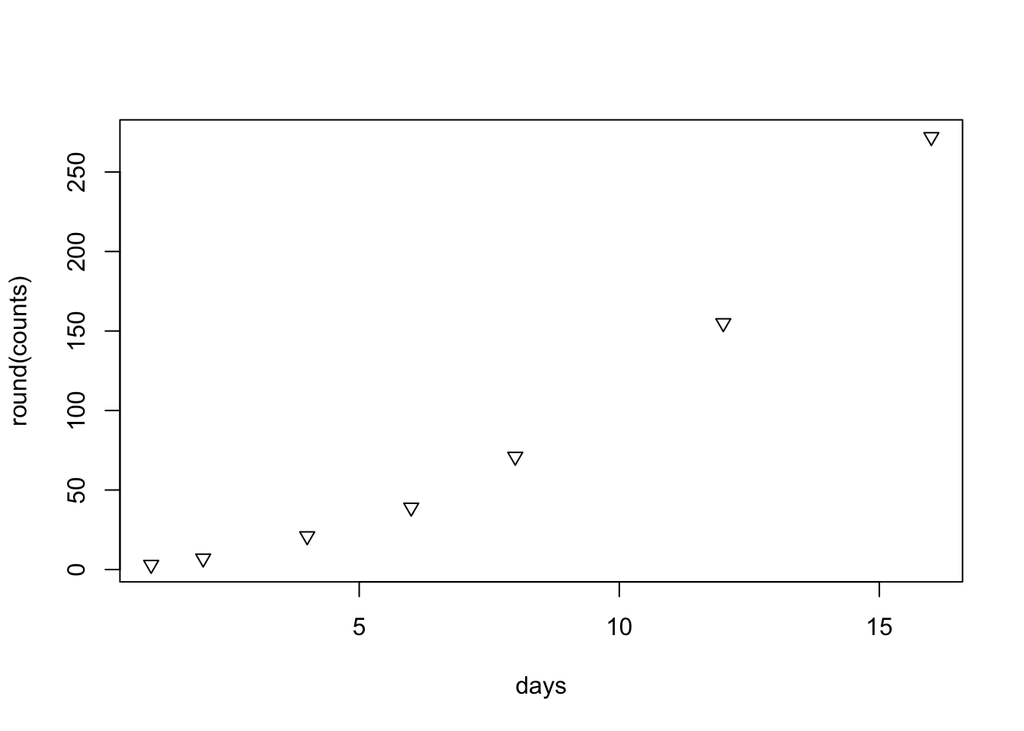

```r
plot.default(days,round(counts), pch=6)
```

# Exploring and summarizing data

6. Your colleague has supplied you with the following table of data (number of cells per sample volume):

| Day | LineA | LineB | LineC |
| --- | --- | --- | --- |
| 1 | 4 | 5 | 14 |
| 2 | 9 | 17 | 16 |
| 3 | 7 | 22 | 10 |
| 4 | 12 | 20 | 14 |
| 5 | 23 | 24 | 20 |
| 6 | 8 | 18 | 12 |

Create some R vectors to hold this data and provide summary statisics for number of cells for each cell line. Plot some base R graphs if you like. Describe the data.

```r
day <- c(1,2,3,4,5,6)
line_a <- c(4,9,7,12,23,8)
line_b <- c(5,17,22,20,24,18)
line_c <- c(14,16,10,14,20,12)
summary(line_a)
```

```
##    Min. 1st Qu.  Median    Mean 3rd Qu.    Max.
##    4.00    7.25    8.50   10.50   11.25   23.00
```

```r
summary(line_b)
```

```
##    Min. 1st Qu.  Median    Mean 3rd Qu.    Max.
##    5.00   17.25   19.00   17.67   21.50   24.00
```

```r
summary(line_c)
```

```
##    Min. 1st Qu.  Median    Mean 3rd Qu.    Max.
##   10.00   12.50   14.00   14.33   15.50   20.00
```

```r
#
```

You are then provided with assay data that states that LineA had an activity of 4.2 per cell, LineB an activity of 3.4 and LineC of 1.3.

Use R to calculate the activities of each sample on each day and provide summary statistics of activity for each line.

```r
act_line_a <- line_a * 4.2
act_line_b <- line_b * 3.4
act_line_c <- line_c * 1.3
act_line_a
```

```
## [1] 16.8 37.8 29.4 50.4 96.6 33.6
```

```r
act_line_b
```

```
## [1] 17.0 57.8 74.8 68.0 81.6 61.2
```

```r
act_line_c
```

```
## [1] 18.2 20.8 13.0 18.2 26.0 15.6
```

```r
summary(act_line_a)
```

```
##    Min. 1st Qu.  Median    Mean 3rd Qu.    Max.
##   16.80   30.45   35.70   44.10   47.25   96.60
```

```r
summary(act_line_b)
```

```
##    Min. 1st Qu.  Median    Mean 3rd Qu.    Max.
##   17.00   58.65   64.60   60.07   73.10   81.60
```

```r
summary(act_line_c)
```

```
##    Min. 1st Qu.  Median    Mean 3rd Qu.    Max.
##   13.00   16.25   18.20   18.63   20.15   26.00
```

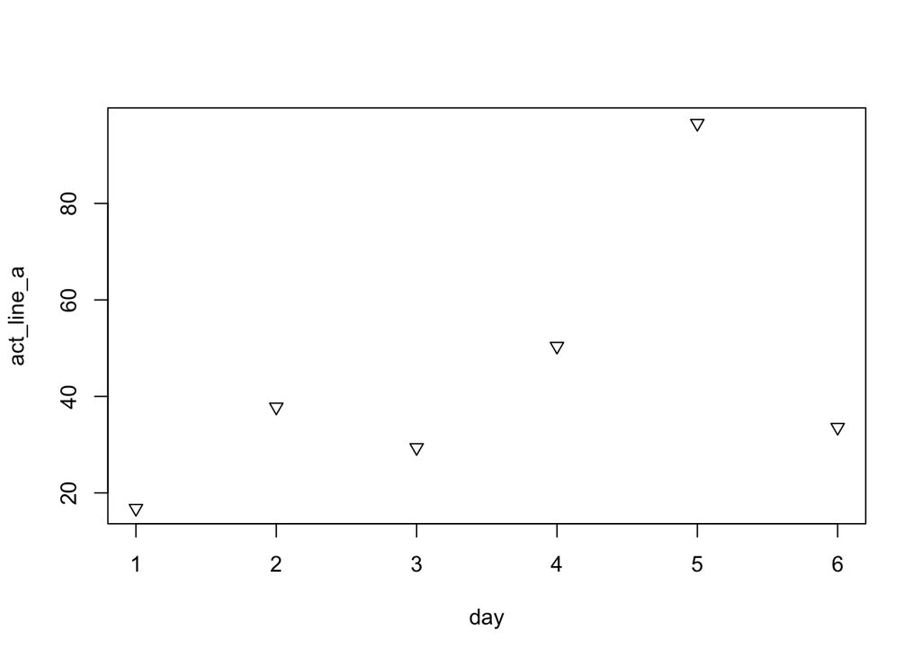

```r
plot.default(day,act_line_a,pch=6)
```

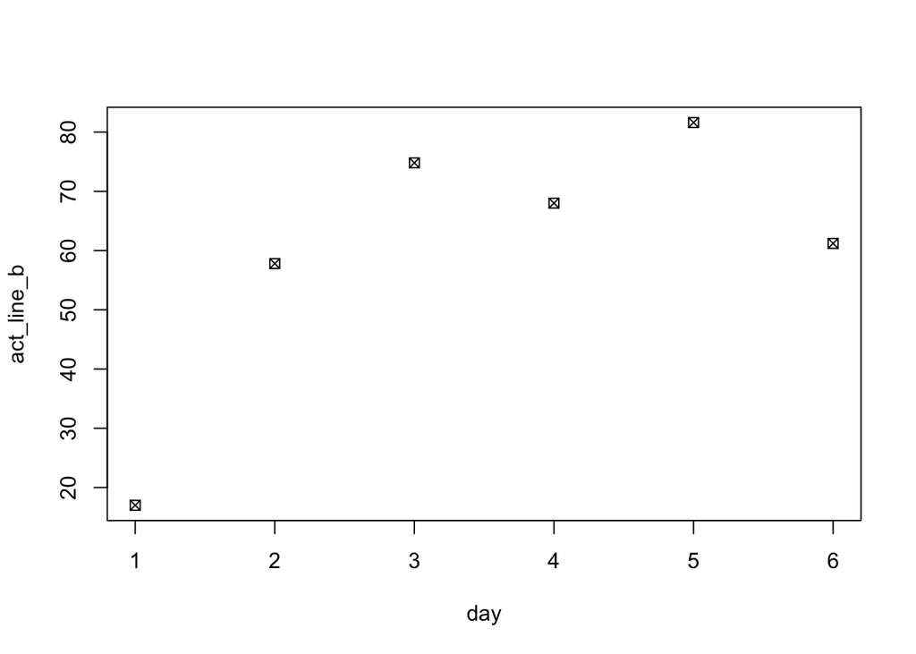

```r
plot.default(day,act_line_b,pch=7)
```

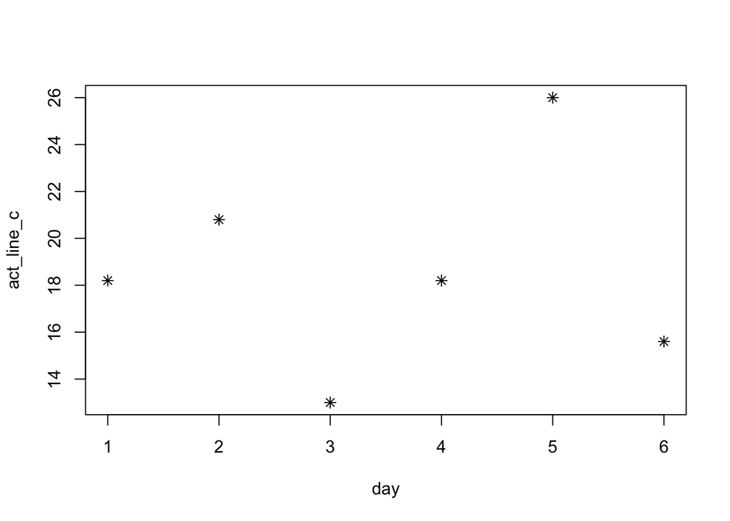

```r
plot.default(day,act_line_c,pch=8)
```

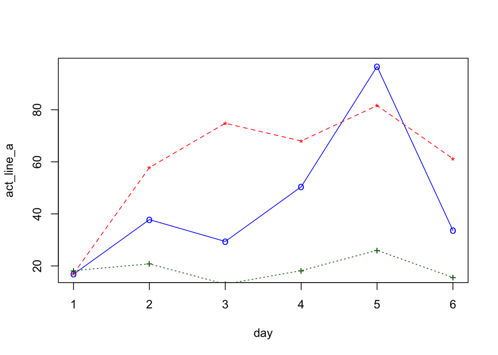

```r
#
# Plot with multiple lines (Yes I had to look it up in help as I don't tend to use base R plot very often)

# plot the first curve by calling plot() function
# First curve is plotted
 plot(day, act_line_a, type="o", col="blue", pch="o", lty=1 )

# Add second curve to the same plot by calling points() and lines()
# Use symbol '*' for points.
 points(day, act_line_b, col="red", pch="*")
 lines(day, act_line_b, col="red",lty=2)

# Add Third curve to the same plot by calling points() and lines()
# Use symbol '+' for points.
 points(day, act_line_c, col="dark green",pch="+")
 lines(day, act_line_c, col="dark green", lty=3)
```

# Creating a report for your assignment

Click on the ‘Knit’ menu at the top of this file and select either whichever option you prefer to create an HTML, PDF or Word document version of your assignment. This will run all the code chunks and “knit” the resulting results with the surrounding text to produce a report.